# STA260 Final Project

Bo Zhang, Cindy Li, Mingrui Gao

2022-06-01

## Abstract

Knowing the price trends for hotels and flights and important factors affecting the trends are critical for both travelers and associated service providers: travelers can plan relatively cost-effective trips and service providers are able to adjust their strategies based on the trends. They can also improve travel or service plans by adjusting the levels of significant features. In this project, we web scraped hotel and flight information from Booking.com to prepare the datasets for analysis. Data cleaning, such as parsing, handling missing values, and feature encodings are done afterwards. For the exploratory data analysis section, various visualizations and techniques are used to help us gain profound insights from the data. In addition, conclusions and recommendations are included in the last few sections.

## Introduction

### Background

It is well known that the hotel and flight prices would fluctuate along with the market conditions, which will lead to a large difference for people traveling during different seasons and to different places. There are many different reasons that will influence the hotel price. Price would be higher if there are a large number of hotels provided in that area; the reservation date is really close to the travel date; the travel time is during the peak tourist season in that area. For example, if we are interested in scheduling travel to Miami, it would be much more expensive to travel during February than during August, since the temperature in February in Miami is around 25°C, which is much better than in August, say 32°C.

There was an interesting thing that we found last December when I was scheduling the trip to Hawaii. The flight price was more than $400 if we traveled from Dec. 17 to Dec. 22, but only $250 if we traveled from Dec. 15 to Dec. 20. It was only 2 days later, but the price will be 60% higher. Postponing this trip for 2 days would not really affect our plan, but would save our budget a lot, thus it would be really meaningful to have a reference for us to see how to plan for a cheaper trip without reducing the travel experience.

Therefore, we are interested in what features will make the flight significantly different. In this project, we will focus on three major cities as destinations that we are interested in traveling to, which are Honolulu, New York, and Las Vegas. The departure city would be San Francisco. The time period we will be mainly focused on is from July 1st, 2022 to July 31st, 2022, which would give us insight and suggestions for the travel price during this summer vacation. The information we will be referred to would be from Booking.com.

### Questions of Interest

1. What feature makes the flight price different, and what are the important features?
2. What are the important features that affect the hotel price?
3. How to choose the duration, and start date to plan for a cheaper but higher quality trip?

## Data Scraping

Prior to data analysis in R, we conducted web scraping to collect the datasets from Booking.com using Python. For hotel data, the features we decided to collect are: hotel name, hotel location, distance from city center, room type, bed type, number of reviews, rating, cancellation policy, availability (number of rooms left), and the price per night. For flight data, the features we chose to scrape are: departure time, departure date, departure airport, arrival time, arrival date, arrival airport, flight duration, number of stops, airline name, and the price. The scraped data for hotel and flight are stored in separate dataframes and exported to CSV files for future data pre-processing and exploratory data analysis.

### Scrape Hotel Information from Booking.com

For scraping the hotel information, we started simply by utilizing the ‘requests’ and ‘BeautifulSoup’ packages embedded in Python for requesting web pages, using website developer tools for inspecting and locating target features, and looping through dates and pages for search results from all three cities.

#### Build a Hotel Scraper Function (Single Page)

Firstly, on a Booking.com search result page, we opened the developer tools to inspect elements of the web page and locate the features to be included in the hotel data frame. Generally, the ‘div’ tag is used for setting divisions or sections in an HTML document, which can include any sort of content; the ‘span’ tag in HTML documents functions as an inline container for marking up a part of a text or document. The ‘div’ and ‘span’ tags are similar to each other, however, ‘div’ is usually used as a block-level element while ‘span’ is used as an inline element. The ‘class’ attribute following the ‘div’ or ‘span’, or other tags, is used for pointing to a class name in a style sheet, which allows elements under specific class names to be accessed and manipulated. Basically, the format used for locating certain features looks like these: (‘span’, {‘data-testid’: ‘distance’}), or (‘div’, {‘class’: ‘cb1f9edcd4’}, etc.

After knowing the tags and classes for all features, we constructed a for loop to find and store the values on any web page requested from the URL being passed into the loop. If the section of a certain feature on the page is blank, NA is filled into the corresponding space in the list. All values on a single web page for every feature will be stored in separate lists, and these lists are concatenated into a data frame.

#### Build a URL Generation Function for Each Date

To generate URLs for all dates ranging from 2022-07-01 to 2022-07-31, we need to inspect the general format of URL when making a search on Booking.com. The format is composed with a check-in date as well as a check-out date, such as ‘checkin=2022-07-01&checkout=2022-07-02’, at a specific location in the entire URL. Hence, we first obtained a list for all dates using a for loop. Afterward, we built another for loop for substituting all dates in the list into a general URL template so that we had all the URLs corresponding to the dates.

#### Build a URL Generation Function for Each Page

After taking care of the issue of dates, we also realized that there are multiple pages of results per day searched. However, back at the beginning of our project, we haven’t figured out how to scroll through pages automatically. Therefore, we decided to collect the URLs for different pages using a similar methodology as we did in generating URLs for different dates. It turns out that there are 25 properties displayed on a single page. For a new page, a text corpus in the format of ’offset=25*page number’ is added to the URL. We retrieved the total number of properties displayed on the first page per search for every date, calculated the total number of pages by dividing 25, and appended the ‘offset=xxx’ portion to the URL for the first page. By passing all the date URLs we obtained earlier into the for loop, we got the list containing all the URLs in the unit of page.

#### Generate Final Dataframe

First of all, we formed a list to include general URLs for the 3 destinations: Honolulu, NYC, and Las Vegas. Then, we passed the initial URLs to the date URL generation function to have a list of URLs for dates, used the list as input for the page URL generation function to obtain a list of page URLs, and called the hotel scraper function on the final URLs iteratively. Finally, data frames acquired for different pages were combined into a final one and exported to a CSV file.

### Scrape Flight Information from Booking.com (Autonomous Scrolling)

Since it took a long time to request the information using the implementations for scraping hotel information, we decided to improve the scraping efficiency with Selenium Chrome Driver in Python to achieve autonomous scrolling between the pages. The rest of the scraping procedures are basically the same as scraping hotel information interpreted in the previous section.

#### Build a Flight Scraper Function with Automation

We took exactly the same steps for inspecting the flight search result pages and locating the elements we wanted as we did in the hotel scraping phase. However, here we utilized the Selenium WebDriver to request HTML instead of using BeautifulSoup and requests packages. Selenium WebDriver is a web framework, which enables the user to execute cross-browser tests and commands. This tool is used in automating web-based applications, and is supported by multiple programming platforms. In this case, we created a Chrome Driver instance, which controls the browser and navigates to the desired webpage (its URL) by itself. For locating the web elements (the feature we choose to include in the dataframe), locators in selenium will be used. There are different locators in Selenium that perform various functionalities: ‘find_element_by_id’ locates elements by their CSS IDs; ‘find_element_by_class_name’ locates elements by their class names; ‘find_element_by_attirbute’ enables us to retrieve elements by their name attributes; ‘find_element_by_xpath’ helps us to locate elements with their DOM structures. In our function, we used the ‘find_elemenet_by_xpath’ locator, and the DOM structures are simply the stuff such as ‘div’, ‘span’, and ‘class’ we used in the hotel section.

To achieve automatic page scrolling, we simply built a ‘next page button’ in the while loop we used for acquiring and storing the elements on web pages. Firstly, we still used the ‘find_element_by_xpath’ locator to find the ‘next page’ label on the website. Then, we implement a ‘click()’ function to take over the control over that button. Finally, we built a while loop, and put all the element locators, as well as the next page button we built after all the locators into it. By doing these, we were able to retrieve all the features from one page then scroll to the next page automatically until reaching the end of all search result pages. Similarly, the features scraped are stored in lists and concatenated to dataframes.

#### Build a URL Generation Function for Each Date

Since we achieved the automation for scrolling, the function for generating URLs for different pages were no longer needed. However, we still need to generate URLs for the dates from July. Here, we used exactly the same methodology from the hotel dates URL generator function by substituting the departure dates into the general URLs for the flight search results in the format of ‘depart=2022-07-01’. There is no need to consider the departure date since we limited the search to one-way tickets only.

#### Generate Final Dataframe

After constructing the function discussed above, we called the functions with the same sequence as that in the hotel section. However, we encountered a ‘TimeoutException’ error while the Selenium ChromeDriver was navigating through different pages, and we couldn’t fix it within a limited timeframe. As a result, we didn’t retrieve all the flight data for the entire date range we planned so we only used the hotel dataset for our EDA tasks.

## Data Preprocessing

### Parse the Scraped Data

After the scraping process, we parsed the data. Specifically speaking, we copied the text from ‘room_type’ to fill the blanks from ‘bed_type’. We deleted the punctuations in columns ‘location’, ‘bed_type’, ‘reviews’, ‘availability’, ‘policy’, and ‘price’. For column ‘distance_center’, we remove the text “miles from center”, leaving only the number.

### Change to Numeric Variables

For columns ‘price’, ‘reviews’, ‘distance_center’, they were recognized as character variables after we scrapped them from websites. So we transformed them into numerical variables before analyzing them. ### Encoding for ‘cancellation’ variable From scraping, we got a column names policy, indicating whether a hotel has the “free cancellation” policy. We transformed that into a binary categorical variable name “cancellation” that contains true and false.

### Add ‘weekday’ Column

Since we want to see the pattern through weekdays, we add a weekday column to the dataset. One of our goals for our project is to investigate the price patterns through the weekdays. So we form a column called “Weekday” and added it to the data frame.

[figure not shown]

### Change ‘rating’ to Categorical Variable

There is a ‘rating’ column in our dataset. Since this column has 1.0-10.0 as its values, it will be easier to see the trend by setting this column as a categorical variable, instead of using these many scattered values. There is an official setting on Booking.com as we look at all the hotels. We are interested in checking whether these categories are reasonable or not, or if there are any other settings that are more scientific based on the ratings themselves.

Therefore we used a Hierarchical Clustering based on the Mutual Conditional Entropy of ratings. Hierarchical clustering starts by treating each rating score as a separate cluster and repeatedly merging the two closest clusters until all the clusters are combined together. The method we are referring to when measuring the distance between two clusters is mutual conditional entropy, which is how much uncertainty this pair has with each other.

The group settings are shown below (the same color represents the same group), the column has been named as ‘satisfaction’:

[figure not shown]

## Exploratory Data Analysis

### Dataset Introduction

Table continues below

| checkin | checkout | city | hotel |
| --- | --- | --- | --- |
| 2022-07-01 | 2022-07-02 | Honolulu | Ala Moana Hotel - Resort Fee Included |
| 2022-07-01 | 2022-07-02 | Honolulu | ’Alohilani Resort Waikiki Beach |
| 2022-07-01 | 2022-07-02 | Honolulu | Imperial Hawaii Resort |
| 2022-07-01 | 2022-07-02 | Honolulu | Waikiki Resort Hotel |
| 2022-07-01 | 2022-07-02 | Honolulu | Best Western The Plaza Hotel - Free Breakfast |
| 2022-07-01 | 2022-07-02 | Honolulu | Trump International Hotel Waikiki |
| 2022-07-01 | 2022-07-02 | Honolulu | Halekulani |
| 2022-07-01 | 2022-07-02 | Honolulu | Pearl Hotel Waikiki |
| 2022-07-01 | 2022-07-02 | Honolulu | Ramada Plaza by Wyndham Waikiki |
| 2022-07-01 | 2022-07-02 | Honolulu | Hilton Hawaiian Village Waikiki Beach Resort |

Table continues below

| location | distance_center | reviews | rating | availability | price |
| --- | --- | --- | --- | --- | --- |
| Downtown Honolulu | 1.7 | 1480 | 7.9 | 4 | 314 |
| Waikiki | 3.1 | 1508 | 8.2 | 7+ | 594 |
| Waikiki | 2.6 | 1152 | 8.4 | 1 | 245 |
| Waikiki | 3.1 | 1984 | 8.1 | 7+ | 309 |
| Western Honolulu | 4.1 | 1060 | 7.5 | 7+ | 239 |
| Waikiki | 2.5 | 480 | 9.3 | 7 | 729 |
| Waikiki | 2.6 | 415 | 9.2 | 7+ | 705 |
| Waikiki | 2.8 | 374 | 7.2 | 3 | 189 |
| Waikiki | 2 | 1490 | 8.1 | 1 | 219 |
| Waikiki | 2.1 | 1985 | 7.8 | 7+ | 351 |

| weekday | cancellation | satisfaction |
| --- | --- | --- |
| Friday | True | good |
| Friday | True | very good |
| Friday | True | very good |
| Friday | True | very good |
| Friday | True | good |
| Friday | True | wonderful |
| Friday | True | wonderful |
| Friday | True | pleasant |
| Friday | True | very good |
| Friday | False | good |

Based on the data Scraping from Booking and all the precious data cleaning process, we get our final dataset. There are 20611 rows and 13 columns in total, the introduction of each column is:

| Column_Name | Description |
| --- | --- |
| **checkin** | check in date |
| **checkout** | check out date |
| **city** | destination city |
| **hotel** | hotel name |
| **location** | specific area within that city |
| **distance_center** | distance from the hotel to the center of the city |
| **reviews** | total review number |
| **rating** | overall rating based on the rating provided by customers |
| **availability** | amount of room available a this price in this hotel |
| **price** | price per room per night |
| **weekday** | Mon/ Tue/ Wed/ Thur/ Fri/ Sat/ Sun |
| **cancellation** | free cancellation or not |
| **satisfaction** | Satisfaction level based on the rating provided by the customers |

### General Visualization for Continuous Variables

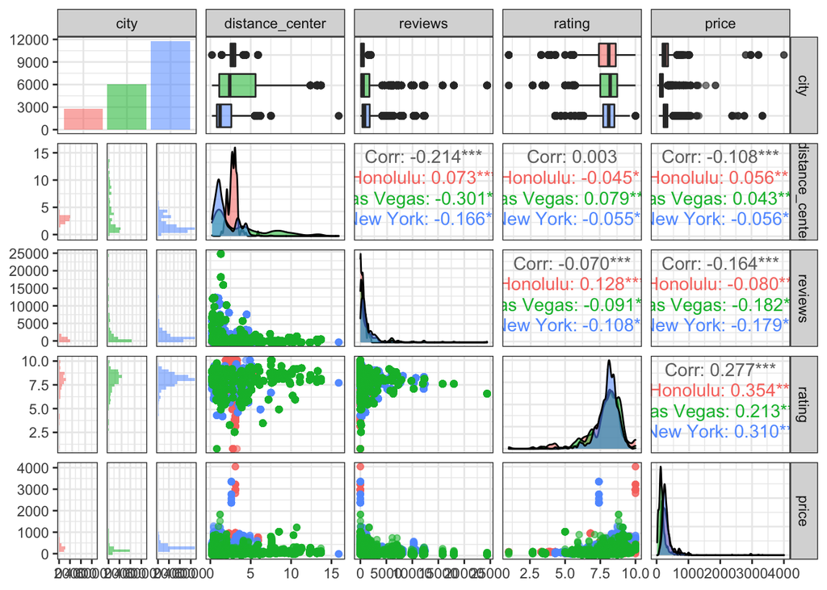

This plot is pretty informative. From the plots of city, we could observe that New York has the highest amount of hotels, approximately twice as in Las Vegas and four times as in Honolulu. From the plots of ‘distance_center’, we can see that the Honolulu hotel price peaks at around 2~3 miles away from the center rather than the center. The hotels rating from 7.5~10.0 generally have very high prices.

### Time Series

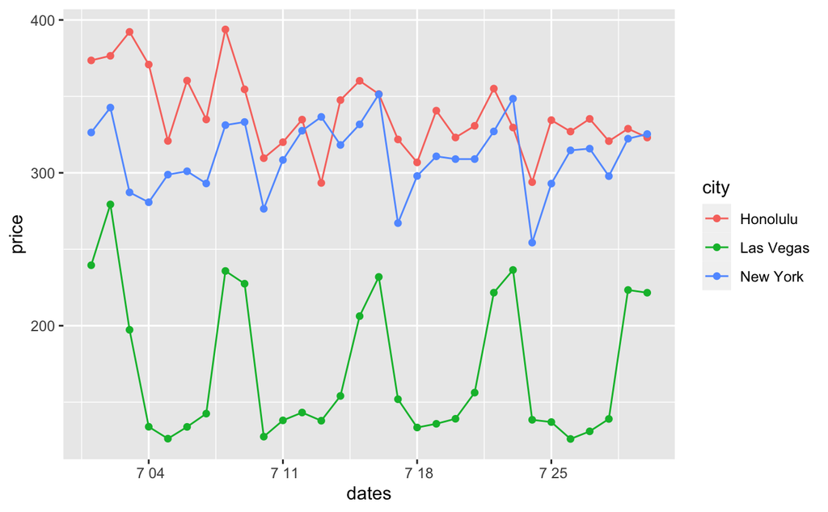

### Heatmap Based on Mutual Conditional Entropy Matrix

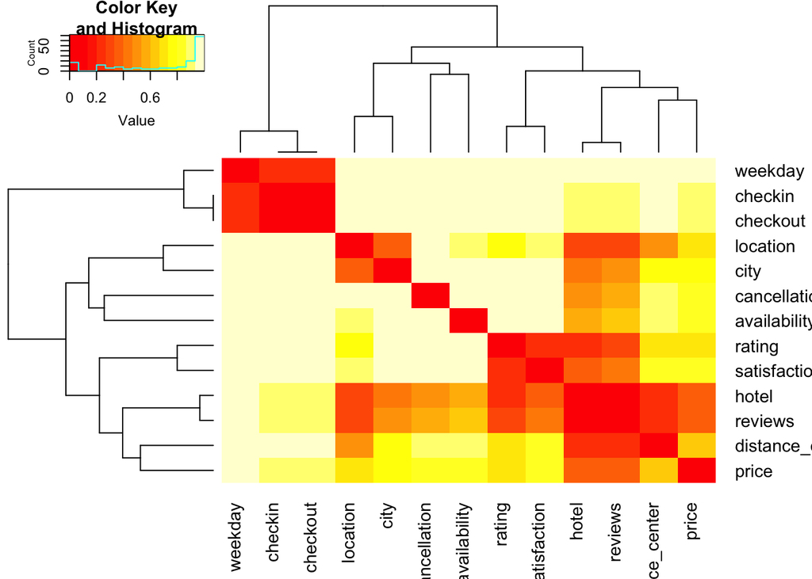

In order to see the relationship within each feature, the Mutual Conditional Entropy Matrix has been calculated. The heatmap is plotted based on the entropy matrix. Since smaller entropy leads to smaller uncertainty, there are several feature pairs having lower conditional entropy than other pairs, which means there is lower uncertainty within these pairs:

1. The pair ‘reviews’ with ‘distance to center’ and the pair ‘reviews’ with ‘location’ have extremely low entropy. This is because people tend to live near the center during travel. There would be more reviews if more people live there compared to other farther hotels. Also, there are several areas that are relatively safe, convenient, have more things to do, or are near to the scenic spots, which would attract more people to live within these areas.
2. As for the pair ‘price’ with ‘distance to center’ and ‘price’ with ‘location’, although it may be thought that closer to the center would have a higher price, this is not always the case. From this plot, there is a correlation but actually not very high between these two features. The city center is important, scenery is also important. There are too many locations in a city with scenery, which makes the entropy between price and location not very small.
3. There is a lower entropy for the pair ‘reviews’ and ‘rating’. This is also following our intuition. People will not live in awful hotels. Lower reviews will not bring the hotel more customers. Higher ratings will make people have a higher tendency to live and bring more ratings in consequence.
4. The entropy for the pair ‘price’ and ‘reviews’ is pretty small, but for the pair ‘price’ and ‘rating’ is relatively high. We could understand this as not only expensive but could provide excellent service and get a higher rating. A cheaper hotel can also provide great service and get a higher rating. As for having a higher number of review hotels, this popularity makes their price higher than others because of the increasing demand.
5. The price is having lower entropy with the ‘date’ rather than ‘weekday’, which means that closer check-in dates tend to have higher prices, no matter whether it’s weekdays or weekends since the date is really close from now.

### Box Plot

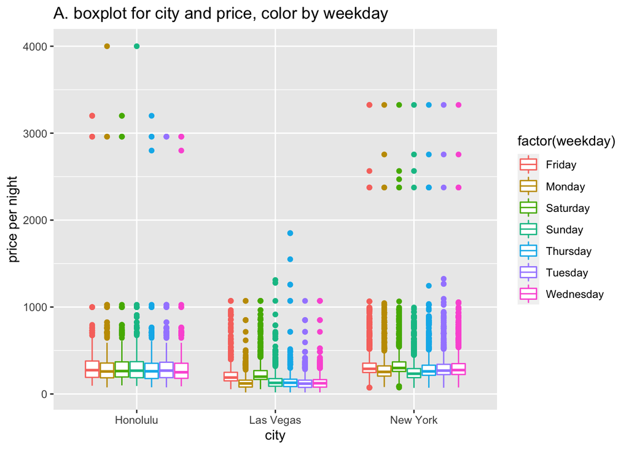

For Honolulu, there is actually no clear difference in the price based on different weekdays. This is because people who go to island cities usually take a long trip. And during pandemics, tons of people choose to work from Hawaii, which makes Hawaii become a really popular place for vacation, higher demand makes the price can not drop in a short period. For New York and Las Vegas, Friday & Saturday usually have higher prices since people tend to schedule a short-term trip or weekend trip to the metropolis. And Las Vegas generally have a lower price than the other two cities, since lots of hotels have casinos inside, which is their major income. Lower living spending will attract more people to live here, and bring more potential outcomes.

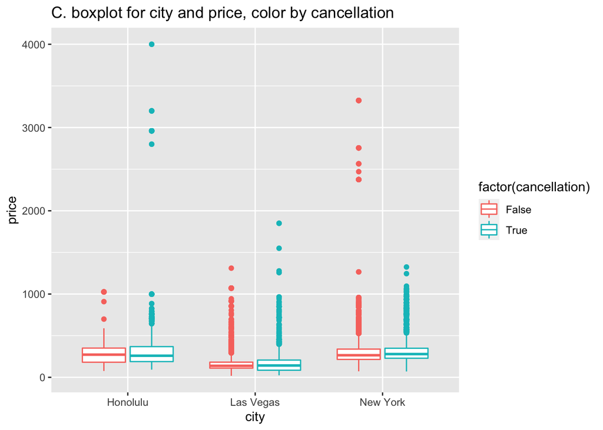

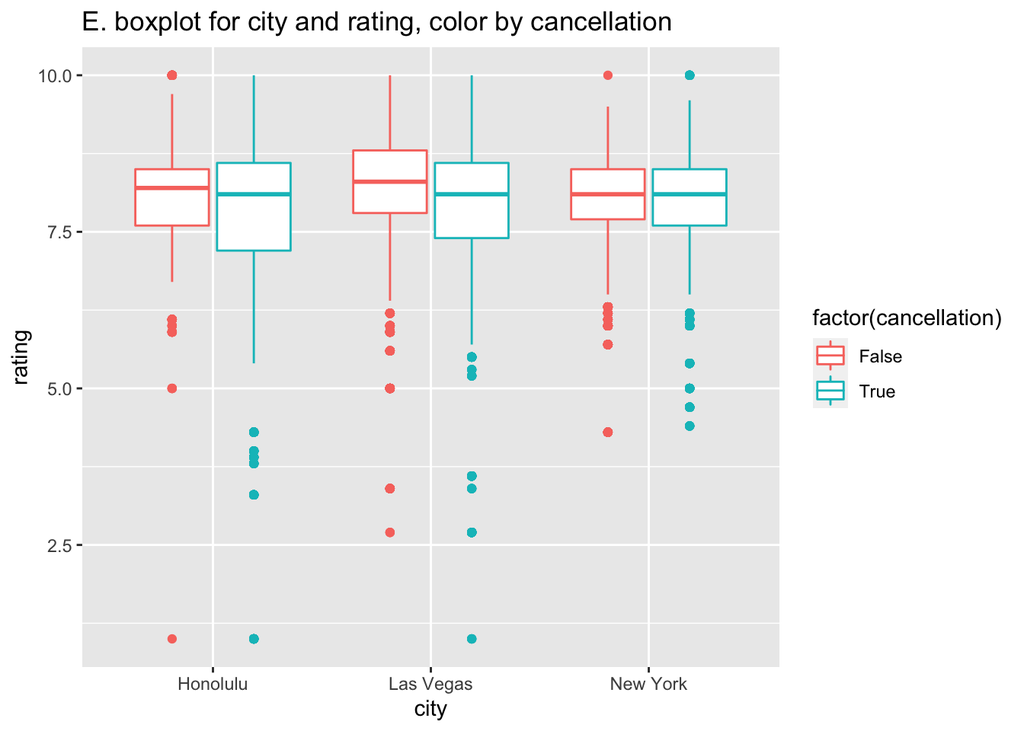

From boxplot E, we can observe that there is no clear difference for rating colored by the cancellation policy.

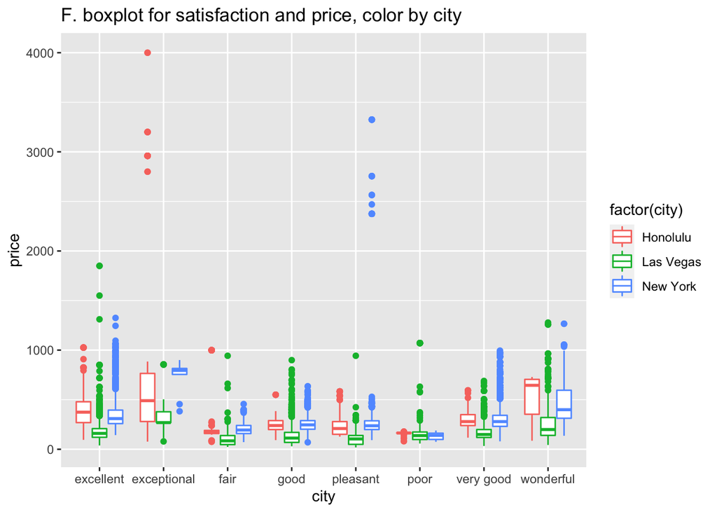

## Conclusion

From the heatmap, there isn’t a strong correlation between price and distance to the center. This is actually reasonable as we think of the city we chose.

It may be relatively expensive to live in the center of a mega city such as New York or Chicago, since the price of land is extremely high in that area, which leads to a higher fixed cost of holding a hotel at the center. Therefore, it may contain more luxury hotels rather than ordinary hotels, since customers who have a higher probability to spend relatively high prices would have a tendency to live in a luxury hotel, and think highly of hotel quality, instead of the cost performance. Besides, ordinary hotels also need to raise their prices to cover all the expenses at the center. However, since the hotels we chose to analyze are New York, Las Vegas, and Honolulu, that is only the case for New York.

As we think about Las Vegas, hotels in the center always have casinos inside. The casino is one of their major ways to earn money. In order to attract people to spend money in casinos, lowering the living price could make it easier for people to walk around casinos. This would be a free advertisement. The core principle of advertising is to accurately deliver high-quality content to potential customer groups. People who live in these hotels would be the best target audience, since people who travel to Las Vegas mostly know this city primarily for its gambling, entertainment, and nightlife. This group of people will possess a high curiosity about it and leisure travel makes them have enough time to spend on it. For those business travel people, their spare time would be mainly from late afternoon to midnight, this would be the best time to gamble and club. Besides, passenger flow volume would be really high. In general, this whole population would have both money and time to spend.

As for Honolulu, this would be a completely different story. Honolulu is an island city, which is mostly famous for islands, although also famous for shopping, but this is not as important as islands. People have a higher passion to live along the beach with those sea-view rooms. Therefore, the distance to the city center is not that important for people who travel to Honolulu.

## Limitation & Future Improvements

For future improvements, we could also scrape the flight price, join the flight pice and hotel price together, and analyze the following questions:  
1. Will the hotel amount or hotel price of a city influence the flight price?  
2. Will the flight price of a city influence the hotel price?

This way we could have a more comprehensive analysis of the travel spending, and give a better understanding of the trend of the flight and hotel price, which could lead to a more accurate estimation of the whole trip expense and provide a better suggestion on when to travel.

Besides, we only worked on giving insights of this summer and only three cities that our group was interested in for planning a trip due to the time limit and technical issues. If we could have a better server and have more time to work on this project, our final goal is to scrape a whole year of data for the major cities as departure and destination cities. It could automatically update by the time, and eventually, give travelers suggested hotel and airline lists based on their budget, time duration, and all other settings for the travel.

Lastly, we also have a small suggestion for the website: there is too much redundant information for the room type and bed type features. It would be more clear for travelers to read and pick up the key words if there could be a regulation for the hotel to fill in the type, without leaving these as free response features. Hotels just copy paste room and bed type, making these two modules become meaningless.

## Reference

1. Miami temperatures: Averages by month. Miami FL Average Temperatures by Month - Current Results. (n.d.). Retrieved June 7, 2022, from https://www.currentresults.com/Weather/Florida/Places/miami-temperatures-by-month-average.php
2. HTML tag. HTML div tag. (n.d.). Retrieved June 7, 2022, from https://www.w3schools.com/tags/tag_div.asp
3. HTML tag. HTML span tag. (n.d.). Retrieved June 7, 2022, from https://www.w3schools.com/tags/tag_span.asp
4. HTML class attribute. HTML Classes - The Class Attribute. (n.d.). Retrieved June 7, 2022, from https://www.w3schools.com/html/html_classes.asp
5. Data-* - HTML: Hypertext markup language: MDN. HTML: HyperText Markup Language | MDN. (n.d.). Retrieved June 7, 2022, from https://developer.mozilla.org/en-US/docs/Web/HTML/Global_attributes/data-*
6. Selenium webdriver tutorial with examples. BrowserStack. (2022, February 11). Retrieved June 7, 2022, from https://www.browserstack.com/guide/selenium-webdriver-tutorial

## Appendix - R Code

The code for Data Analysis is attached below. And the code for web scraping using python would be attached in the separate file named ‘Final Project_Scraping.html’.

```r
knitr::opts_chunk$set(echo = TRUE)
library(ggplot2)
library(car)
library(plotly)
library(dplyr)
library(gplots)
library(corrplot)
library(GGally)
library(data.table)
library(fastDummies)
library(pander)
library(cowplot)
library(DT)
library(tidyverse)
library(stats)
# function: Entropy, Mutual Conditional Entropy, Mutual Conditional Entropy Matrix, Directional Association

#calculate entropy
Entropy = function(x){
  entropy = -sum(x*log(x), na.rm = T)
  return(entropy)
}

#Calculate Directional Association
DirAssoc =  function(dc1, dc2){
  if (length(dc1) != length(dc2)){
    stop('Check! Two digital-coding sequences should have the same length!')
  }
  n = length(dc1) # sample size
  cont.table = table(dc1, dc2) # contingency table
  cond.prop = proportions(cont.table, margin = 2) # conditional row proportions given column category
  cond.entropy = apply(cond.prop, 2, Entropy) # conditional entropy given column category
  marg.prop = table(dc1) / n # marginal row proportions
  marg.entropy = Entropy(marg.prop) # marginal entropy
  rescaled.entropy = cond.entropy / marg.entropy
  weight = table(dc2) / n # marginal column proportions used as weights
  dir.assoc = sum(weight * rescaled.entropy)
  return(dir.assoc)
}

# Calculate Mutual Conditional Entropy
MCE = function(dc1, dc2){
  MCE = (DirAssoc(dc1, dc2) + DirAssoc(dc2, dc1)) / 2
  return(MCE)
}

# Calculate Mutual Conditional Entropy Matrix
MCEMatrix = function(k, dc.list){
  entropy.matrix = matrix(0, k, k)
  for (i in 1:k){
    for (j in 1:k){
      dc1 = dc.list[[i]]
      dc2 = dc.list[[j]]
      entropy.matrix[i,j] = MCE(dc1, dc2)
    }
  }
  colnames(entropy.matrix) = rownames(entropy.matrix) = names(dc.list)
  return(entropy.matrix)
}
hp = read.csv('3city1mo_parsed.csv')
hp = select(hp, -X)
hp$checkin <- as.Date(hp$checkin)
hp$checkout <- as.Date(hp$checkout)
hp$weekday <- weekdays(hp$checkin)
hp$reviews[hp$reviews == ''] <- NA
hp$policy[hp$policy == ''] <- NA
hp$distance_center <- sub(",","",hp$distance_center)
hp$distance_center <- as.numeric(hp$distance_center)
hp$reviews <- sub(",","",hp$reviews)
hp$reviews <- as.numeric(hp$reviews)
hp$price <- sub(",","",hp$price)
hp$price <- as.numeric(hp$price)
hp$cancellation = 'True'
hp$cancellation[which(is.na(hp$policy))] = 'False'
hp = select(hp, -policy, -room_type, -bed_type)
hp <- na.omit(hp)
colSums(is.na(hp))
## hc tree for scores to defind the level of rating
dataf <- dummy_cols(hp, select_columns = 'rating')
dataf <- dataf[,c(13:68)]
entropy.matrix2 = MCEMatrix(56, dataf)
dist_mat <- as.dist(entropy.matrix2)
hc_acc_rf_x = hclust(dist_mat, method = "ward.D2")
plot(hc_acc_rf_x)
cut_avg = rect.hclust(hc_acc_rf_x, k = 3, border = 2:6)
knitr::include_graphics("table.png")
satisfaction <- vector(length=length(hp$rating))
for (i in 1:length(hp$rating)) {
  if (hp$rating[i] < 6) {
    satisfaction[i] = 'poor'
  } else if (6 <= hp$rating[i] & hp$rating[i] < 7) {
    satisfaction[i] = 'fair'
  } else if (7 <= hp$rating[i] & hp$rating[i] < 7.5) {
    satisfaction[i] = 'pleasant'
  } else if (7.5 <= hp$rating[i] & hp$rating[i] < 8) {
    satisfaction[i] = 'good'
  } else if (8 <= hp$rating[i] & hp$rating[i] < 8.5) {
    satisfaction[i] = 'very good'
  } else if (8.5 <= hp$rating[i] & hp$rating[i] < 9) {
    satisfaction[i] = 'excellent'
  } else if (9 <= hp$rating[i] & hp$rating[i] < 9.5) {
    satisfaction[i] = 'wonderful'
  } else if (9.5 <= hp$rating[i] & hp$rating[i] <= 10) {
    satisfaction[i] = 'exceptional'
  }
}
hp$satisfaction = satisfaction
pander(hp[1:10,])
#datatable(hp, options = list(pageLength = 5))
a = select(hp, city, distance_center, reviews, rating, price)
#b = select(hp, city, availability, weekday, cancellation)

ggpairs(a,aes(color = city, alpha=0.8))+theme_grey(base_size=9)+theme_bw()
#ggpairs(b,aes(color = city, alpha=0.8))+theme_grey(base_size=9)+theme_bw()
dates <- names(table(hp$checkin))
dates = as.Date(dates)

average_honolulu <- vector(length=length(dates))
for (i in 1:length(dates)) {
  average_honolulu[i] = sum(hp$price[hp$checkin==dates[i] & hp$city=='honolulu'])/length(hp$price[hp$checkin==dates[i] & hp$city=='honolulu'])
}
print(sum(hp$price[hp$checkin==dates[1] & hp$city=='honolulu']))


average_lasvegas <- vector(length=length(dates))
for (i in 1:length(dates)) {
  average_lasvegas[i] = sum(hp$price[hp$checkin==dates[i] & hp$city=='las vegas'])/length(hp$price[hp$checkin==dates[i] & hp$city=='las vegas'])
}

average_newyork <- vector(length=length(dates))
for (i in 1:length(dates)) {
  average_newyork[i] = sum(hp$price[hp$checkin==dates[i] & hp$city=='new york'])/length(hp$price[hp$checkin==dates[i] & hp$city=='new york'])
}

df1 = data.frame(dates = dates, price = average_honolulu, city = rep('Honolulu', 30))
df2 = data.frame(dates = dates, price = average_newyork, city = rep('New York', 30))
df3 = data.frame(dates = dates, price = average_lasvegas, city = rep('Las Vegas', 30))
df_time_series = rbind(df1,df2,df3)
df_time_series$weekday = weekdays(df_time_series$dates)

ggplot(df_time_series, aes(x=dates, y=price)) + geom_line(aes(colour=city)) +geom_point(aes(colour=weekday))
knitr::include_graphics("time series.png")
# calculate MCE matrix
entropy.matrix = MCEMatrix(13, hp)

# plot the heatmap
heatmap.2(entropy.matrix, symm = T, trace = "none", key = T, revC = T)
#relationships between cluster, race, and level of depression
box_plot_df <- select(hp, city, price, weekday, cancellation)
box_plot_df$price[box_plot_df$price > 1500] <- NA
box_plot_df <- na.omit(box_plot_df)

q1 = ggplot(hp, aes(x = city, y = price, color=factor(weekday)))+geom_boxplot() +
  labs(x="city", y='price per night', title="A. boxplot for city and price, color by weekday")
q1
#q2 = ggplot(box_plot_df, aes(x = city, y = price, color=factor(weekday)))+geom_boxplot() +
#  labs(x="city", y='price per night', title="B. boxplot for city and price, color by weekday (reduced)")

#plot_grid(q1, q2, nrow = 2)
q3 = ggplot(hp, aes(x = city, y = price, color=factor(cancellation)))+geom_boxplot() +
  labs(x="city", y='price', title="C. boxplot for city and price, color by cancellation")
q3
#q4 = ggplot(box_plot_df, aes(x = city, y = price, color=factor(cancellation)))+geom_boxplot() +
#  labs(x="city", y='price', title="D. boxplot for city and price, color by cancellation (reduced)")

#plot_grid(q3, q4, nrow = 2)
q5 = ggplot(hp, aes(x = city, y = rating, color=factor(cancellation)))+geom_boxplot() +
  labs(x="city", y='rating', title="E. boxplot for city and rating, color by cancellation")
q5
q6 = ggplot(hp, aes(x = satisfaction, y = price, color=factor(city)))+geom_boxplot() +
  labs(x="city", y='price', title="F. boxplot for satisfaction and price, color by city")
q6
#q7 = ggplot(hp, aes(x = satisfaction, y = reviews, color=factor(city)))+geom_boxplot() +
#  labs(x="city", y='reviews', title="G. boxplot for satisfaction and reviews, color by city")

#plot_grid(q6, q7, nrow = 2)
#plot_grid(q1, q2, q3, q4, q5, q6, q7, ncol = 2, labels = "AUTO")


### island city: no one will go only for one day, corona -> people work from hawaii
```